# **Facial Emotion Detection**

## **Milestone 1**

## **Problem Definition**

1. Problem Definition

Context

Facial emotion recognition has several applications. They could be a biomedical application for measurement of mental health of patients in a hospital setting or measuring the customer’s response and mood while shopping, recognize emotions of employees to measure ‘happiness index’, or whether a user is suffering from ‘depression’ or if the driver of a vehicle is ‘happy’ and ‘cheerful’ enough for a safe driving etc.,

Objectives

The objective of this capstone project is to explore and employ deep learning approaches in order to develop a computer vision model which can accurately detect facial expressions. This can then be used for follow-up applications in the detection of emotion. The goal is to make use of the algorithm to provide a multi-output classification emotion from varying facial expressions.

Key Questions

How good the data is organized? How is the data identified? How many types and categories of expressions are represented in the provided dataset? How accurate the model should be for effective classification? Will CNN be more efficient than ANN in the emotion classification accuracy?

Problem Formulation Can a machine learning model be able to identify, recognize the facial expressions with superior accuracy so that the follow-up applications can be used for determining the correct emotional state of the human beings.

## **About the dataset**

The data set consists of 3 folders, i.e., 'test', 'train', and 'validation'. Each of these folders has four subfolders:

**‘happy’**: Images of people who have happy facial expressions.  
**‘sad’**: Images of people with sad or upset facial expressions.  
**‘surprise’**: Images of people who have shocked or surprised facial expressions.  
**‘neutral’**: Images of people showing no prominent emotion in their facial expression at all.

## **Important Notes**

- This notebook can be considered a guide to refer to while solving the problem. The evaluation will be as per the Rubric shared for each Milestone. Unlike previous courses, it does not follow the pattern of the graded questions in different sections. This notebook would give you a direction on what steps need to be taken to get a feasible solution to the problem. Please note that this is just one way of doing this. **There can be other 'creative' ways to solve the problem, and we encourage you to feel free and explore them as an 'optional' exercise**.
- In the notebook, there are markdown cells called Observations and Insights. It is a good practice to provide observations and extract insights from the outputs.
- The naming convention for different variables can vary. **Please consider the code provided in this notebook as a sample code.**
- All the outputs in the notebook are just for reference and can be different if you follow a different approach.
- There are sections called **Think About It** in the notebook that will help you get a better understanding of the reasoning behind a particular technique/step. Interested learners can take alternative approaches if they want to explore different techniques.

## **Mounting the Drive**

**NOTE:** Please use Google Colab from your browser for this notebook. **Google.colab is NOT a library that can be downloaded locally on your device.**

```python
# Mounting the drive
from google.colab import drive
drive.mount('/content/drive')
```

## **Importing the Libraries**

```python
import zipfile
import matplotlib.pyplot as plt
import numpy as np
import pandas as pd
import seaborn as sns
import os

# Importing Deep Learning Libraries

from tensorflow.keras.preprocessing.image import load_img, img_to_array
from tensorflow.keras.preprocessing.image import ImageDataGenerator
from tensorflow.keras.layers import Dense, Input, Dropout, GlobalAveragePooling2D, Flatten, Conv2D, BatchNormalization, Activation, MaxPooling2D, LeakyReLU
from tensorflow.keras.models import Model, Sequential
from tensorflow.keras.optimizers import Adam, SGD, RMSprop
```

### **Let us load the data**

**Note:**

- You must download the dataset from the link provided on Olympus and upload the same on your Google drive before executing the code in the next cell.
- In case of any error, please make sure that the path of the file is correct as the path may be different for you.

```python
# Storing the path of the data file from the Google drive
path = '/content/drive/MyDrive/Facial_emotion_images.zip'

# The data is provided as a zip file so we need to extract the files from the zip file
with zipfile.ZipFile(path, 'r') as zip_ref:
    zip_ref.extractall()
```

```python
picture_size = 48
folder_path = "Facial_emotion_images/"
```

## **Visualizing our Classes**

Let's look at our classes.

**Write down your observation for each class. What do you think can be a unique feature of each emotion, that separates it from the remaining classes?**

### **Happy**

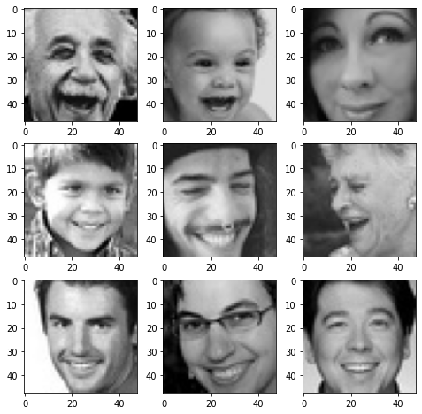

```python
expression = 'happy'

plt.figure(figsize= (8,8))
for i in range(1, 10, 1):
    plt.subplot(3, 3, i)

    img = load_img(folder_path + "train/" + expression + "/" +
                  os.listdir(folder_path + "train/" + expression)[i], target_size = (picture_size, picture_size))
    plt.imshow(img)

plt.show()
```

**Observations and Insights:__** Dataset is composed of representations of multiple types of happy expressions. The mouth of the human beings in most of the images seems to be open exposing the teeth, with expanded upper and lower lips. However, the diversity is not included in the dataset concerning the skin tone, concerning the multicultural and multi-ethnic human beings because there may be cultural differences in terms of the expression of happiness may not have been included. For example: Japanese and Koreans tend not to expose the teeth for showing happiness compared to the westerners. There is a possibility for overfitting an accurate training datset. The upturn corner of the mouth (joining area between lower and upper lips), raised cheeks, eyes are distinctly different compared to the rest of the 3 classes.

### **Sad**

```python
# Write your code to visualize images from the class 'sad'.
```

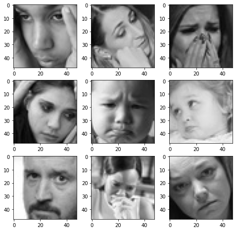

```python
expression = 'sad'

plt.figure(figsize= (8,8))
for i in range(1, 10, 1):
    plt.subplot(3, 3, i)

    img = load_img(folder_path + "train/" + expression + "/" +
                  os.listdir(folder_path + "train/" + expression)[i], target_size = (picture_size, picture_size))
    plt.imshow(img)

plt.show()
```

**Observations and Insights:__** Sad faces dataset has multiple distinguishing features from the happy emotions. The eyes are downward / downturn looking,lips are pouty, wrinkles appear in the forehead, a bit more tightening around the jaw area etc can be seen from the dataset and are some of the defining features.

### **Neutral**

```python
# Write your code to visualize images from the class 'neutral'.
```

[figure not shown]

```python
expression = 'neutral'

plt.figure(figsize= (8,8))
for i in range(1, 10, 1):
    plt.subplot(3, 3, i)

    img = load_img(folder_path + "train/" + expression + "/" +
                  os.listdir(folder_path + "train/" + expression)[i], target_size = (picture_size, picture_size))
    plt.imshow(img)

plt.show()
```

**Observations and Insights:__** This is challenging to label or recognize as neutral. Based on the visual judgement of the neutral dataset, we could assume that CNN could provide better classfication than the ANN. There may be a need for data augmentation. Some of the distinct features in comparison to the other classes are - lack of major emotions, a plain look, eye brows appear normal and forehead has no wrinkles, no tightness along the upper and lower lip joining area, lack of cheeks rising to the eyes etc.

### **Surprised**

```python
# Write your code to visualize images from the class 'surprise'.
```

[figure not shown]

```python
expression = 'surprise'

plt.figure(figsize= (8,8))
for i in range(1, 10, 1):
    plt.subplot(3, 3, i)

    img = load_img(folder_path + "train/" + expression + "/" +
                  os.listdir(folder_path + "train/" + expression)[i], target_size = (picture_size, picture_size))
    plt.imshow(img)

plt.show()
```

**Observations and Insights:__** The dataset shows distinct features and appears to be clean. The images have similar dimensions across the data sets. Wideness of the yes, raising eyebrows, gaping mouths, raised eyebrows similar to a tilted 'c' shape are some potential distinct features of surprise facial emotion expression. The images in all the datasets for all 4 classes vary in size and are positionally different on within the frame of the picture.

## **Checking Distribution of Classes**

```python
# Getting count of images in each folder within our training path
num_happy = len(os.listdir(folder_path + "train/happy"))
print("Number of images in the class 'happy':   ", num_happy)

num_sad = len(os.listdir(folder_path + "train/sad"))
print("Number of images in the class 'sad':  ", num_sad)

num_neutral = len(os.listdir(folder_path + "train/neutral"))
print("Number of images in the class 'neutral':   ", num_neutral)

num_surprise = len(os.listdir(folder_path + "train/surprise"))
print("Number of images in the class 'surprise':  ", num_surprise)
```

```
Number of images in the class 'happy':    3976
Number of images in the class 'sad':   3982
Number of images in the class 'neutral':    3978
Number of images in the class 'surprise':   3173
```

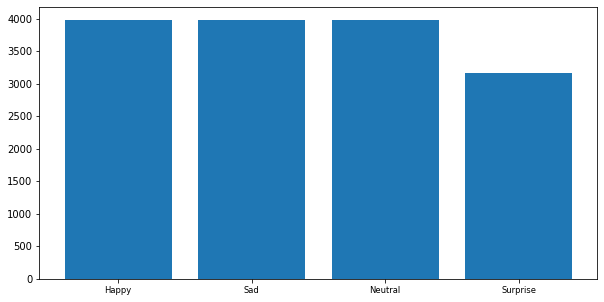

```python
# Code to plot histogram
plt.figure(figsize = (10, 5))

data = {'Happy': num_happy, 'Sad': num_sad, 'Neutral': num_neutral, 'Surprise' : num_surprise}

df = pd.Series(data)

plt.bar(range(len(df)), df.values, align = 'center')

plt.xticks(range(len(df)), df.index.values, size = 'small')

plt.show()
```

**Observations and Insights:__** In the case of class imbalance, as the minority class is rare and the model sees few examples of it, the model is less confident when predicting it as compared to the majority class which has abundant samples which in turn gives the model more opportunities to learn and hence the model is more confident. In this provided capstone project, the class 'surprise' is a minority class and hence there may be issues regarding training. Substantially less amount of data in the class 'surprise' training data. This will have impact on the efficacy of the training. After the model is built, probably a confusion matrix has to be used for identification to check for loss of efficacy due to the variation in the datasize for surprise class. Normalization of data is another approach that could reduce this variation in the datasize among the classes.

To deal with the imbalance, there may be two approaches. One is resampling method in which we can remove the samples from the 3 classes namely sad, neutral and happy so that the total number of samples are more or less equal to the class 'surprise'. Alternatively, we can do 'data augmentation' method to increase the sample size of 'surprise'. This can be done by either rotating the images, or changing the grayscale values or pixelating the images to increase the number of images so that they are more or less equal to the rest of the 3 classes.

**Think About It:**

- Are the classes equally distributed? If not, do you think the imbalance is too high? Will it be a problem as we progress?
- Are there any Exploratory Data Analysis tasks that we can do here? Would they provide any meaningful insights?

## **Creating our Data Loaders**

In this section, we are creating data loaders that we will use as inputs to our Neural Network. A sample of the required code has been given with respect to the training data. Please create the data loaders for validation and test set accordingly.

**You have two options for the color_mode. You can set it to color_mode = 'rgb' or color_mode = 'grayscale'. You will need to try out both and see for yourself which one gives better performance.**

```python
batch_size  = 32
img_size = 48

datagen_train = ImageDataGenerator(horizontal_flip = True,
                                    brightness_range=(0.,2.),
                                    rescale=1./255,
                                    shear_range=0.3)

train_set = datagen_train.flow_from_directory(folder_path + "train",
                                              target_size = (img_size, img_size),
                                              color_mode = 'rgb',
                                              batch_size = batch_size,
                                              class_mode = 'categorical',
                                              shuffle = True)

datagen_validation = ImageDataGenerator(horizontal_flip = True,
			brightness_range=(0.,2.),
			rescale=1./255,
			shear_range=0.3)

validation_set = datagen_validation.flow_from_directory(folder_path + "validation",
                                              target_size = (img_size, img_size),
                                              color_mode = 'rgb',
                                              batch_size = batch_size,
                                              class_mode = 'categorical',
                                              shuffle = True)

datagen_test = ImageDataGenerator(horizontal_flip = True,
			brightness_range=(0.,2.),
			rescale=1./255,
			shear_range=0.3)

test_set = datagen_test.flow_from_directory(folder_path + "test",
                                              target_size = (img_size, img_size),
                                              color_mode = 'rgb',
                                              batch_size = batch_size,
                                              class_mode = 'categorical',
                                              shuffle = True)
```

```
Found 15109 images belonging to 4 classes.
Found 4977 images belonging to 4 classes.
Found 128 images belonging to 4 classes.
```

## **Model Building**

The images are placed in different sizes and varying special orinetations. Filter strides will maintain fidelity. Before flattening the images, there is a need to explore the understanding of the images. The ability to share the weights in the CNN will offer the model with the total value of the image, rather just a single point in enhancing the classificiation accuracy.

**Think About It:**

- Are Convolutional Neural Networks the right approach? Should we have gone with Artificial Neural Networks instead?
- What are the advantages of CNNs over ANNs and are they applicable here?

### **Creating the Base Neural Network**

Our Base Neural network will be a fairly simple model architecture.

- We want our Base Neural Network architecture to have 3 convolutional blocks.
- Each convolutional block must contain one Conv2D layer followed by a maxpooling layer and one Dropout layer. We can play around with the dropout ratio.
- Add first Conv2D layer with **64 filters** and a **kernel size of 2**. Use the 'same' padding and provide the **input_shape = (48, 48, 3) if you are using 'rgb' color mode in your dataloader or else input shape = (48, 48, 1) if you're using 'grayscale' colormode**. Use **'relu' activation**.
- Add MaxPooling2D layer with **pool size = 2**.
- Add a Dropout layer with a dropout ratio of 0.2.
- Add a second Conv2D layer with **32 filters** and a **kernel size of 2**. Use the **'same' padding** and **'relu' activation.**
- Follow this up with a similar Maxpooling2D layer like above and a Dropout layer with 0.2 Dropout ratio to complete your second Convolutional Block.
- Add a third Conv2D layer with **32 filters** and a **kernel size of 2**. Use the **'same' padding** and **'relu' activation.** Once again, follow it up with a Maxpooling2D layer and a Dropout layer to complete your third Convolutional block.
- After adding your convolutional blocks, add your Flatten layer.
- Add your first Dense layer with **512 neurons**. Use **'relu' activation function**.
- Add a Dropout layer with dropout ratio of 0.4.
- Add your final Dense Layer with 4 neurons and **'softmax' activation function**
- Print your model summary

```python
# Initializing a Sequential Model
model1 = Sequential()

# Add the first convolutional block
model1.add(Conv2D(64,(2,2), padding = 'same', activation = 'relu', input_shape = (48, 48, 3)))
model1.add(MaxPooling2D(2, 2))
model1.add(Dropout(rate = 0.2))
#Add second convolutional block
model1.add(Conv2D(32, (2, 2), padding = 'same', activation = 'relu'))
model1.add(MaxPooling2D(2, 2))
model1.add(Dropout(rate = 0.2))
#Add the third convolutional block
model1.add(Conv2D(32, (2, 2), padding = 'same', activation = 'relu'))
model1.add(MaxPooling2D(2, 2))
model1.add(Dropout(rate = 0.2))
# Add the Flatten Layer
model1.add(Flatten())
#Add the first Dense Layer
model1.add(Dense(512, activation = 'relu'))
model1.add(Dropout (rate = 0.4))
#Add the Final Layer
model1.add(Dense(4, activation = 'softmax'))
model1.summary()
```

```
Model: "sequential_8"
_________________________________________________________________
 Layer (type)                Output Shape              Param #
=================================================================
 conv2d_21 (Conv2D)          (None, 48, 48, 64)        832

 max_pooling2d_19 (MaxPoolin  (None, 24, 24, 64)       0
 g2D)

 dropout_4 (Dropout)         (None, 24, 24, 64)        0

 conv2d_22 (Conv2D)          (None, 24, 24, 32)        8224

 max_pooling2d_20 (MaxPoolin  (None, 12, 12, 32)       0
 g2D)

 dropout_5 (Dropout)         (None, 12, 12, 32)        0

 conv2d_23 (Conv2D)          (None, 12, 12, 32)        4128

 max_pooling2d_21 (MaxPoolin  (None, 6, 6, 32)         0
 g2D)

 dropout_6 (Dropout)         (None, 6, 6, 32)          0

 flatten_5 (Flatten)         (None, 1152)              0

 dense_11 (Dense)            (None, 512)               590336

 dropout_7 (Dropout)         (None, 512)               0

 dense_12 (Dense)            (None, 4)                 2052

=================================================================
Total params: 605,572
Trainable params: 605,572
Non-trainable params: 0
_________________________________________________________________
```

### **Compiling and Training the Model**

```python
from keras.callbacks import ModelCheckpoint, EarlyStopping, ReduceLROnPlateau

checkpoint = ModelCheckpoint("./model1.h5", monitor='val_acc', verbose=1, save_best_only=True, mode='max')

early_stopping = EarlyStopping(monitor = 'val_loss',
                          min_delta = 0,
                          patience = 3,
                          verbose = 1,
                          restore_best_weights = True
                          )

reduce_learningrate = ReduceLROnPlateau(monitor = 'val_loss',
                              factor = 0.2,
                              patience = 3,
                              verbose = 1,
                              min_delta = 0.0001)

callbacks_list = [early_stopping, checkpoint, reduce_learningrate]

epochs = 20
```

```python
# Write your code to compile your model1. Use categorical crossentropy as your loss function, Adam Optimizer with 0.001 learning rate, and set your metrics to 'accuracy'.
model1.compile(optimizer = Adam(learning_rate = 0.001), loss = 'categorical_crossentropy', metrics = 'accuracy')
```

```python
history = model1.fit(x= train_set, validation_data = validation_set, epochs = 20)
```

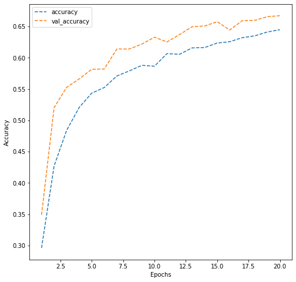

```python
# Write your code to evaluate your model on test data.
dict_hist = history.history
list_ep = [i for i in range(1, 21)]
plt.figure(figsize = (8, 8))
plt.plot(list_ep, dict_hist['accuracy'], ls = '--', label = 'accuracy')
plt.plot(list_ep, dict_hist['val_accuracy'], ls = '--', label = 'val_accuracy')
plt.ylabel('Accuracy')
plt.xlabel('Epochs')
plt.legend()
plt.show()
```

**Observations and Insights:__** Results are not very good, poor, validation accuracy was running simultaneously to the training accuracy. Its about 67% accurate, which is very poor. Both the RGB and the greyscale options provide similar results.

### **Creating the second Convolutional Neural Network**

In the second Neural network, we will add a few more Convolutional blocks. We will also use Batch Normalization layers.

- This time, each Convolutional block will have 1 Conv2D layer, followed by a BatchNormalization, LeakuRelU, and a MaxPooling2D layer. We are not adding any Dropout layer this time.
- Add first Conv2D layer with **256 filters** and a **kernel size of 2**. Use the 'same' padding and provide the **input_shape = (48, 48, 3) if you are using 'rgb' color mode in your dataloader or else input shape = (48, 48, 1) if you're using 'grayscale' colormode**. Use **'relu' activation**.
- Add your BatchNormalization layer followed by a LeakyRelU layer with Leaky ReLU parameter of **0.1**
- Add MaxPooling2D layer with **pool size = 2**.
- Add a second Conv2D layer with **128 filters** and a **kernel size of 2**. Use the **'same' padding** and **'relu' activation.**
- Follow this up with a similar BatchNormalization, LeakyRelU, and Maxpooling2D layer like above to complete your second Convolutional Block.
- Add a third Conv2D layer with **64 filters** and a **kernel size of 2**. Use the **'same' padding** and **'relu' activation.** Once again, follow it up with a BatchNormalization, LeakyRelU, and Maxpooling2D layer to complete your third Convolutional block.
- Add a fourth block, with the Conv2D layer having **32 filters**.
- After adding your convolutional blocks, add your Flatten layer.
- Add your first Dense layer with **512 neurons**. Use **'relu' activation function**.
- Add the second Dense Layer with **128 neurons** and use **'relu' activation** function.
- Add your final Dense Layer with 4 neurons and **'softmax' activation function**
- Print your model summary

```python
# Creating sequential model
model2 = Sequential()

# Add the first Convolutional block
model2.add(Conv2D(256, (2, 2), padding = 'same', input_shape = (48, 48, 3)))
model2.add(BatchNormalization())
model2.add(LeakyReLU(alpha = 0.1))
model2.add(MaxPooling2D(2, 2))

# Add the second Convolutional block
model2.add(Conv2D(128, (2, 2), padding = 'same'))
model2.add(BatchNormalization())
model2.add(LeakyReLU(alpha = 0.1))
model2.add(MaxPooling2D(2, 2))

# Add the third Convolutional block
model2.add(Conv2D(64, (2, 2), padding = 'same'))
model2.add(BatchNormalization())
model2.add(LeakyReLU(alpha = 0.1))
model2.add(MaxPooling2D(2, 2))

# Add the fourth Convolutional block
model2.add(Conv2D(32, (2, 2), padding = 'same'))
model2.add(BatchNormalization())
model2.add(LeakyReLU(alpha = 0.1))
model2.add(MaxPooling2D(2, 2))

# Add the Flatten layer
model2.add(Flatten())

# Adding the Dense layers
model2.add(Dense(512, activation = 'relu'))
model2.add(Dense(128, activation = 'relu'))
model2.add(Dense(4, activation = 'softmax'))
model2.summary()
```

```
Model: "sequential_7"
_________________________________________________________________
 Layer (type)                Output Shape              Param #
=================================================================
 conv2d_17 (Conv2D)          (None, 48, 48, 256)       3328

 batch_normalization_14 (Bat  (None, 48, 48, 256)      1024
 chNormalization)

 leaky_re_lu_12 (LeakyReLU)  (None, 48, 48, 256)       0

 max_pooling2d_15 (MaxPoolin  (None, 24, 24, 256)      0
 g2D)

 conv2d_18 (Conv2D)          (None, 24, 24, 128)       131200

 batch_normalization_15 (Bat  (None, 24, 24, 128)      512
 chNormalization)

 leaky_re_lu_13 (LeakyReLU)  (None, 24, 24, 128)       0

 max_pooling2d_16 (MaxPoolin  (None, 12, 12, 128)      0
 g2D)

 conv2d_19 (Conv2D)          (None, 12, 12, 64)        32832

 batch_normalization_16 (Bat  (None, 12, 12, 64)       256
 chNormalization)

 leaky_re_lu_14 (LeakyReLU)  (None, 12, 12, 64)        0

 max_pooling2d_17 (MaxPoolin  (None, 6, 6, 64)         0
 g2D)

 conv2d_20 (Conv2D)          (None, 6, 6, 32)          8224

 batch_normalization_17 (Bat  (None, 6, 6, 32)         128
 chNormalization)

 leaky_re_lu_15 (LeakyReLU)  (None, 6, 6, 32)          0

 max_pooling2d_18 (MaxPoolin  (None, 3, 3, 32)         0
 g2D)

 flatten_4 (Flatten)         (None, 288)               0

 dense_8 (Dense)             (None, 512)               147968

 dense_9 (Dense)             (None, 128)               65664

 dense_10 (Dense)            (None, 4)                 516

=================================================================
Total params: 391,652
Trainable params: 390,692
Non-trainable params: 960
_________________________________________________________________
```

### **Compiling and Training the Model**

**Hint:** Take reference from the code we used in the previous model for Compiling and Training the Model.

```python
from keras.callbacks import ModelCheckpoint, EarlyStopping, ReduceLROnPlateau

checkpoint = ModelCheckpoint("./model2.h5", monitor='val_loss', verbose = 1, save_best_only = True, mode = 'max')

early_stopping = EarlyStopping(monitor = 'val_loss',
                               min_delta = 0,
                               patience = 3,
                               verbose = 1,
                               restore_best_weights = True
                               )


reduce_learningrate = ReduceLROnPlateau(monitor = 'val_loss',
                                        factor = 0.2,
                                        patience = 3,
                                        verbose = 1,
                                        min_delta = 0.0001
                                        )

callbacks_list = [early_stopping, checkpoint, reduce_learningrate]

epochs = 20
```

```python
model2.compile(loss='categorical_crossentropy',
 optimizer = Adam(learning_rate=0.001),
 metrics=['accuracy'])
```

```python
#history = # Write your code to fit your model2. Use train_set as the training data and validation_set as the validation data. Train your model for 20 epochs.
history = model2.fit(x= train_set, validation_data = validation_set, batch_size = 32, epochs = 20)
```

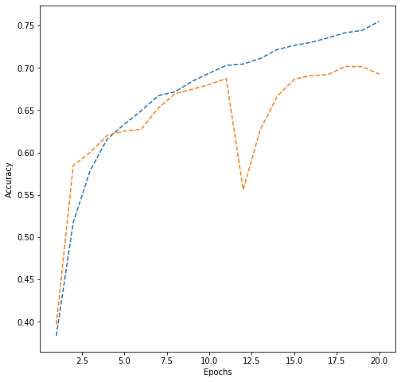

```python
# Write your code to evaluate model's test performance
dict_hist = history.history
list_ep = [i for i in range(1, 21)]
plt.figure(figsize = (8, 8))
plt.plot(list_ep, dict_hist['accuracy'], ls = '--', label = 'accuracy')
plt.plot(list_ep, dict_hist['val_accuracy'], ls = '--', label = 'val_accuracy')
plt.ylabel('Accuracy')
plt.xlabel('Epochs')
```

## **Think About It:**

- Did the models have a satisfactory performance? If not, then what are the possible reasons?
- Which Color mode showed better overall performance? What are the possible reasons? Do you think having 'rgb' color mode is needed because the images are already black and white?

### **Proposed Approach**

- **Potential techniques:** What different techniques should be explored?  
  Data augmentation, may be transfer learning, Parameter and hyperparameter adjustment, deeper hidden layers, Modify overfitting if needed.
- **Overall solution design:** What is the potential solution design?  
  Develop a simpler CNN with deeper parameters
- **Measures of success:** What are the key measures of success to compare different techniques?  
  Accuracy would be the measure of success. Above 90% accuracy can be acceptable. Computational resources or the computing time can also be compared between models as the secondary measures of success after the accuracy.